# Multivariate linear regression

Guillaume Calmettes

8/4/2018

If we look at the dataset we used for the univariate linear case, for each house we have in fact a lot of features, but for the moment we just used their size as predictor of the price.

What if instead of just wanting to predict the price of the houses by just looking at the sizes, we wanted to also include other features, like the number of bedrooms, etc …? Could that help increase our prediction accuracy ?

Since we will include more features, our regression model will be defined as the general form (with $x_0=1$):

$$y=\theta_0\times x_0 +\theta_1\times x_1 +... + \theta_n\times x_n$$

# 1 Cost and gradient descent functions

We can use the exact same gradient descent and cost functions than before, as the way we defined it allows to use any number of features.

```python
import numpy as np

# For correctly shaped theta, features and trueValues matrices, we can define the cost function as
def computeCost(theta, features, trueValues):
    predictions = np.dot(features, theta) # this is a (number of features x number of Theta vectors) matrix
    error = (predictions-trueValues)**2 # if you're inputing a matrice, this won't perform an element-wise square, use np.power instead
    return np.sum(error, axis=0)/(2*features.shape[0])
```

```python
def gradientDescent(startingTheta, features, trueValues, alpha=0.1, maxIterations=1000):
    # number of data in training set
    m = np.array(features).shape[0]

    # We'll compare the theta vector to the next iteration to check convergence
    newTheta = startingTheta
    theta = np.ones_like(newTheta)

    i = 0 # we are setting up a counter to limit max number of iterations if algorithm doesn't converge
    while (newTheta!=theta).all():
        theta = newTheta
        prediction = np.dot(features, theta)
        # derivative for each theta
        derivative = (alpha/m)*np.sum((prediction - trueValues)*features, axis=0)[:, np.newaxis]
        newTheta = newTheta - derivative
        # in case there is no convergence
        i+=1
        if i>=maxIterations:
            break
        yield(np.ravel(newTheta))
```

```python
def rmse(actual, prediction):
    n = len(prediction)
    return np.sqrt(np.sum(np.power(prediction - actual, 2))/n)
```

# 2 Applying multivariate linear regression on the house dataset

```python
import pandas as pd

dataHouses = pd.read_csv("../data/2017-05-12_141127.csv")
```

Santa Monica - House dataset (Zillow - 05/12/2017)

|  | address | city | state | zip | price | sqft | bedrooms | bathrooms | days_on_zillow | sale_type | url |
| --- | --- | --- | --- | --- | --- | --- | --- | --- | --- | --- | --- |
| 1 | 1021 12th St APT 107 | Santa Monica | CA | 90403 | 698000 | 804 | 1 | 1.0 | 1 | Condo For Sale | http://www.zillow.com/homes/for_sale//homedetails/1021-12th-St-APT-107-Santa-Monica-CA-90403/20478727_zpid/ |
| 2 | 913 18th St APT 4 | Santa Monica | CA | 90403 | 1099000 | 1425 | 2 | 3.0 | NaN | Condo For Sale | http://www.zillow.com/homes/for_sale//homedetails/913-18th-St-APT-4-Santa-Monica-CA-90403/20475136_zpid/ |
| 3 | 270 Palisades Beach Rd UNIT 301 | Santa Monica | CA | 90402 | 2999000 | 1590 | 2 | 2.0 | NaN | Coming Soon | http://www.zillow.com/homes/for_sale//homedetails/270-Palisades-Beach-Rd-UNIT-301-Santa-Monica-CA-90402/20486912_zpid/ |
| 4 | 808 5th St APT 7 | Santa Monica | CA | 90403 | 680000 | 980 | 2 | 2.0 | 2 | Condo For Sale | http://www.zillow.com/homes/for_sale//homedetails/808-5th-St-APT-7-Santa-Monica-CA-90403/2094307910_zpid/ |
| 5 | 1919 4th St # A | Santa Monica | CA | 90405 | 2200000 | 2111 | 3 | 3.0 | 1 | Townhouse For Sale | http://www.zillow.com/homes/for_sale//homedetails/1919-4th-St-A-Santa-Monica-CA-90405/2097316419_zpid/ |
| 6 | 1138 12th St APT 5 | Santa Monica | CA | 90403 | 849000 | 1045 | 2 | 2.0 | NaN | Condo For Sale | http://www.zillow.com/homes/for_sale//homedetails/1138-12th-St-APT-5-Santa-Monica-CA-90403/20478785_zpid/ |
| 7 | 1319 11th St APT 6 | Santa Monica | CA | 90401 | 549000 | 558 | 1 | 1.0 | NaN | Condo For Sale | http://www.zillow.com/homes/for_sale//homedetails/1319-11th-St-APT-6-Santa-Monica-CA-90401/20479668_zpid/ |
| 8 | 444 21st St | Santa Monica | CA | 90402 | 7895000 | 7311 | 6 | 8.0 | NaN | House For Sale | http://www.zillow.com/homes/for_sale//homedetails/444-21st-St-Santa-Monica-CA-90402/20476513_zpid/ |
| 9 | 1035 25th St | Santa Monica | CA | 90403 | 2329000 | 1501 | 3 | 2.0 | NaN | House For Sale | http://www.zillow.com/homes/for_sale//homedetails/1035-25th-St-Santa-Monica-CA-90403/20475429_zpid/ |
| 10 | 1307 Berkeley St | Santa Monica | CA | 90404 | 2695000 | 2603 | 5 | 4.0 | 1 | Apartment For Sale | http://www.zillow.com/homes/for_sale//homedetails/1307-Berkeley-St-Santa-Monica-CA-90404/20470335_zpid/ |
| 11 | 933 20th St UNIT B | Santa Monica | CA | 90403 | 1049000 | 1227 | 3 | 2.0 | NaN | Condo For Sale | http://www.zillow.com/homes/for_sale//homedetails/933-20th-St-UNIT-B-Santa-Monica-CA-90403/20475248_zpid/ |
| 12 | 2nd St APT 201 | Santa Monica | CA | 90403 | NaN | 971 | 2 | 2.0 | 10 | Pre-Foreclosure | http://www.zillow.com/homes/for_sale/129611562_zpid/any_days/globalrelevanceex_sort/29.759534,-95.335321,29.675003,-95.502863_rect/12_zm/ |
| 13 | 722 Marine St | Santa Monica | CA | 90405 | 2795000 | 2463 | 4 | 3.0 | NaN | House For Sale | http://www.zillow.com/homes/for_sale//homedetails/722-Marine-St-Santa-Monica-CA-90405/20483309_zpid/ |
| 14 | 933 11th St APT 15 | Santa Monica | CA | 90403 | 819000 | 1018 | 2 | 2.0 | NaN | Condo For Sale | http://www.zillow.com/homes/for_sale//homedetails/933-11th-St-APT-15-Santa-Monica-CA-90403/20478857_zpid/ |
| 15 | 3110 Broadway | Santa Monica | CA | 90404 | 489000 | NaN | 1 | 1.0 | 7 | Condo For Sale | http://www.zillow.com/homes/for_sale//homedetails/3110-Broadway-Santa-Monica-CA-90404/82816526_zpid/ |
| 16 | 1433 Euclid St | Santa Monica | CA | 90404 | 9300000 | 14698 | 26 | 24.0 | 3 | Apartment For Sale | http://www.zillow.com/homes/for_sale//homedetails/1433-Euclid-St-Santa-Monica-CA-90404/2097803579_zpid/ |
| 17 | 1837 Euclid St | Santa Monica | CA | 90404 | 2225000 | 3901 | 0 | NaN | 3 | Apartment For Sale | http://www.zillow.com/homes/for_sale//homedetails/1837-Euclid-St-Santa-Monica-CA-90404/2094325481_zpid/ |
| 18 | 1130 Georgina Ave | Santa Monica | CA | 90402 | 6495000 | 2325 | 3 | 2.0 | 7 | House For Sale | http://www.zillow.com/homes/for_sale//homedetails/1130-Georgina-Ave-Santa-Monica-CA-90402/20477549_zpid/ |
| 19 | 1240 24th St UNIT 3 | Santa Monica | CA | 90404 | 1299000 | 1803 | 3 | 3.0 | NaN | Apartment For Sale | http://www.zillow.com/homes/for_sale//homedetails/1240-24th-St-UNIT-3-Santa-Monica-CA-90404/20474535_zpid/ |
| 20 | 1113 24th St | Santa Monica | CA | 90403 | 1995000 | NaN | 4 | 3.0 | 6 | House For Sale | http://www.zillow.com/homes/for_sale//homedetails/1113-24th-St-Santa-Monica-CA-90403/2098029479_zpid/ |
| 21 | 1225 Washington Ave APT 3 | Santa Monica | CA | 90403 | 639000 | 589 | 1 | 1.0 | 7 | Condo For Sale | http://www.zillow.com/homes/for_sale//homedetails/1225-Washington-Ave-APT-3-Santa-Monica-CA-90403/20478675_zpid/ |
| 22 | 2311 4th St APT 310 | Santa Monica | CA | 90405 | 925000 | 979 | 2 | 2.0 | 8 | Condo For Sale | http://www.zillow.com/homes/for_sale//homedetails/2311-4th-St-APT-310-Santa-Monica-CA-90405/20484219_zpid/ |
| 23 | 628 20th St | Santa Monica | CA | 90402 | 3695000 | 3063 | 5 | 2.5 | 8 | House For Sale | http://www.zillow.com/homes/for_sale//homedetails/628-20th-St-Santa-Monica-CA-90402/20476600_zpid/ |
| 24 | 415 23rd St | Santa Monica | CA | 90402 | 3795000 | 3100 | 3 | 3.0 | NaN | House For Sale | http://www.zillow.com/homes/for_sale//homedetails/415-23rd-St-Santa-Monica-CA-90402/20476050_zpid/ |
| 25 | 900 Euclid St APT 108 | Santa Monica | CA | 90403 | 1200000 | 1384 | 2 | 2.0 | NaN | Condo For Sale | http://www.zillow.com/homes/for_sale//homedetails/900-Euclid-St-APT-108-Santa-Monica-CA-90403/20478588_zpid/ |
| 26 | 2602 25th St | Santa Monica | CA | 90405 | 1969000 | 1838 | 4 | 2.0 | NaN | House For Sale | http://www.zillow.com/homes/for_sale//homedetails/2602-25th-St-Santa-Monica-CA-90405/20473096_zpid/ |
| 27 | 1756 Franklin St | Santa Monica | CA | 90404 | 1725000 | 3180 | 5 | 5.0 | 7 | Apartment For Sale | http://www.zillow.com/homes/for_sale//homedetails/1756-Franklin-St-Santa-Monica-CA-90404/2094358620_zpid/ |
| 28 | 621 Marguerita Ave | Santa Monica | CA | 90402 | 12495000 | 6500 | 6 | 9.0 | 10 | House For Sale | http://www.zillow.com/homes/for_sale//homedetails/621-Marguerita-Ave-Santa-Monica-CA-90402/20486225_zpid/ |
| 29 | 1610 Broadway | Santa Monica | CA | 90404 | 9125000 | 11211 | 15 | 16.0 | 22 | Apartment For Sale | http://www.zillow.com/homes/for_sale//homedetails/1610-Broadway-Santa-Monica-CA-90404/2106454742_zpid/ |
| 30 | 2215 Dewey St | Santa Monica | CA | 90405 | 3850000 | 4500 | 5 | 5.0 | NaN | House For Sale | http://www.zillow.com/homes/for_sale//homedetails/2215-Dewey-St-Santa-Monica-CA-90405/2111948923_zpid/ |

[output cut: 130 more lines]

````
```python
import altair as alt

houses = alt.Chart(dataHouses).mark_circle().encode(
    alt.Color('bathrooms:Q',
        scale=alt.Scale(scheme='viridis')),
    x='sqft:Q',
    y='price:Q',
    size='bedrooms',
    tooltip=['price', 'sqft', 'bedrooms', 'bathrooms']
    ).configure_mark(opacity=0.7).interactive()
````

## 2.1 Features scaling

Like we did before, we’ll normalize our features

```python
featuresOfInterest = ["sqft", "bedrooms", "bathrooms"]

filteredData = dataHouses[np.concatenate([["price"], featuresOfInterest])].dropna()
normalizedFeatures = (filteredData[featuresOfInterest]-filteredData[featuresOfInterest].mean())/filteredData[featuresOfInterest].std()
```

Normalized features

|  | sqft | bedrooms | bathrooms |
| --- | --- | --- | --- |
| 0 | -0.832 | -0.841 | -0.861 |
| 1 | -0.586 | -0.554 | -0.283 |
| 2 | -0.520 | -0.554 | -0.572 |
| 3 | -0.762 | -0.554 | -0.572 |
| 4 | -0.314 | -0.266 | -0.283 |
| 5 | -0.737 | -0.554 | -0.572 |
| 6 | -0.930 | -0.841 | -0.861 |
| 7 | 1.751 | 0.596 | 1.163 |
| 8 | -0.556 | -0.266 | -0.572 |
| 9 | -0.118 | 0.309 | 0.006 |
| 10 | -0.664 | -0.266 | -0.572 |
| 12 | -0.174 | 0.021 | -0.283 |
| 13 | -0.747 | -0.554 | -0.572 |
| 15 | 4.683 | 6.346 | 5.788 |
| 17 | -0.229 | -0.266 | -0.572 |
| 18 | -0.436 | -0.266 | -0.283 |
| 20 | -0.918 | -0.841 | -0.861 |
| 21 | -0.763 | -0.554 | -0.572 |
| 22 | 0.064 | 0.309 | -0.427 |
| 23 | 0.079 | -0.266 | -0.283 |
| 24 | -0.602 | -0.554 | -0.572 |
| 25 | -0.422 | 0.021 | -0.572 |
| 26 | 0.111 | 0.309 | 0.296 |
| 27 | 1.429 | 0.596 | 1.452 |
| 28 | 3.299 | 3.184 | 3.476 |
| 29 | 0.635 | 0.309 | 0.296 |
| 30 | -0.649 | -0.554 | -0.283 |
| 31 | -0.358 | -0.266 | -0.283 |
| 33 | 0.794 | 0.309 | 0.874 |
| 34 | -0.899 | -0.841 | -0.861 |

[output cut: 104 more lines]

## 2.2 Gradient descent for multivariate regression

Alright, let’s run gradient descent:

```python
# reshaping features and trueValues vectors
features = np.hstack([np.ones(len(normalizedFeatures))[:, np.newaxis], normalizedFeatures])
trueValues = filteredData.price.values[:, np.newaxis]

# Initial theta values we'll start iterating from. We now have 3 features, so must be size 4
initialTheta = np.random.rand(features.shape[1])[:, np.newaxis]

# we'll run gradient descent with different alpha rates
alphaList = [0.1, 0.3, 0.5]

gdList = [gradientDescent(initialTheta, features, trueValues, alpha=i, maxIterations=1000) for i in alphaList]
descentList = [np.vstack([initialTheta.transpose(), np.vstack(list(gd))]) for gd in gdList]
```

```python
import matplotlib.pyplot as plt
plt.style.use('ggplot')
fig,ax = plt.subplots()

n = 30
for i in range(len(alphaList)):
    theta = descentList[i].transpose()
    ax.plot(np.ravel(computeCost(theta, features, trueValues)), label=r"$\alpha$" f"={alphaList[i]}")
ax.set_xlim(0, n)
```

```
## (0, 30)
```

```python
ax.set_ylim(0, 0.8e13)
```

```
## (0, 8000000000000.0)
```

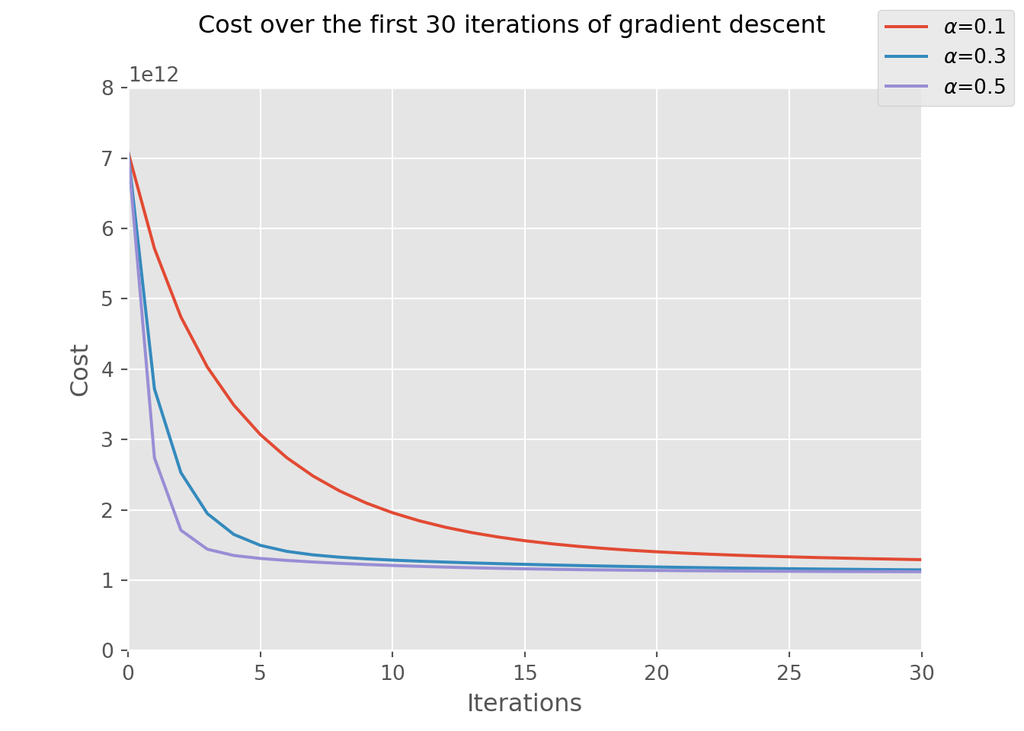

```python
ax.set_xlabel("Iterations")
ax.set_ylabel("Cost")
fig.suptitle(f"Cost over the first {n} iterations of gradient descent")
fig.legend();
plt.show()
```

## 2.3 Model accuracy

Let’s see how the $RMSE$ changed with those added features.

```python
# let's get the theta obtained with alph=0.3
fittedTheta = descentList[1][-1][:, np.newaxis]

predictions = features@fittedTheta

print(f"RMSE: {rmse(trueValues, predictions):.2f}")
```

```
## RMSE: 1493249.92
```

Well, by adding the number of bathrooms and bedrooms as features in addition of the size, it seems that we did improved a bit our predictions as the $RMSE$ is a bit smaller now.

We can check the predicted price for each house compared to the true price.

```python
housePricePredictions = filteredData.loc[:, ["price"]].assign(predicted= lambda x: features@fittedTheta)
housePricePredictions["difference"] = housePricePredictions.price-housePricePredictions.predicted
```

Predicted vs True price

|  | price | predicted | difference |
| --- | --- | --- | --- |
| 0 | 698000 | 1745007 | -1047006.86 |
| 1 | 1099000 | 2320743 | -1221743.04 |
| 2 | 2999000 | 2229394 | 769605.53 |
| 3 | 680000 | 1742107 | -1062106.81 |
| 4 | 2200000 | 2502092 | -302091.54 |
| 5 | 849000 | 1794031 | -945030.91 |
| 6 | 549000 | 1548494 | -999494.14 |
| 7 | 7895000 | 6671847 | 1223152.67 |
| 8 | 2329000 | 1791648 | 537352.00 |
| 9 | 2695000 | 2384972 | 310027.94 |
| 10 | 1049000 | 1572768 | -523767.97 |
| 12 | 2795000 | 2416630 | 378369.92 |
| 13 | 819000 | 1772462 | -953462.44 |
| 15 | 9300000 | 8810307 | 489693.01 |
| 17 | 6495000 | 2449886 | 4045114.25 |
| 18 | 1299000 | 2256051 | -957051.21 |
| 20 | 639000 | 1573258 | -934257.94 |
| 21 | 925000 | 1741308 | -816307.98 |
| 22 | 3695000 | 2417701 | 1277298.94 |
| 23 | 3795000 | 3292137 | 502863.39 |
| 24 | 1200000 | 2064835 | -864835.03 |
| 25 | 1969000 | 1694204 | 274795.95 |
| 26 | 1725000 | 3069054 | -1344054.15 |
| 27 | 12495000 | 6247150 | 6247849.73 |
| 28 | 9125000 | 8272686 | 852313.58 |
| 29 | 3850000 | 4123513 | -273512.69 |
| 30 | 899000 | 2192930 | -1293929.88 |
| 31 | 3269000 | 2413421 | 855578.84 |
| 33 | 6500000 | 4889357 | 1610642.65 |
| 34 | 539000 | 1611602 | -1072601.88 |

[output cut: 104 more lines]

```python
import altair as alt

housesPredChart = alt.Chart(housePricePredictions).mark_circle().encode(
    x='price',
    y='predicted',
    size='difference',
    tooltip = alt.Tooltip(['price:Q', 'predicted:Q', 'difference:Q'], format= "s")
    ).configure_mark(opacity=0.7).interactive()
```

And that’s what the residual plot looks like

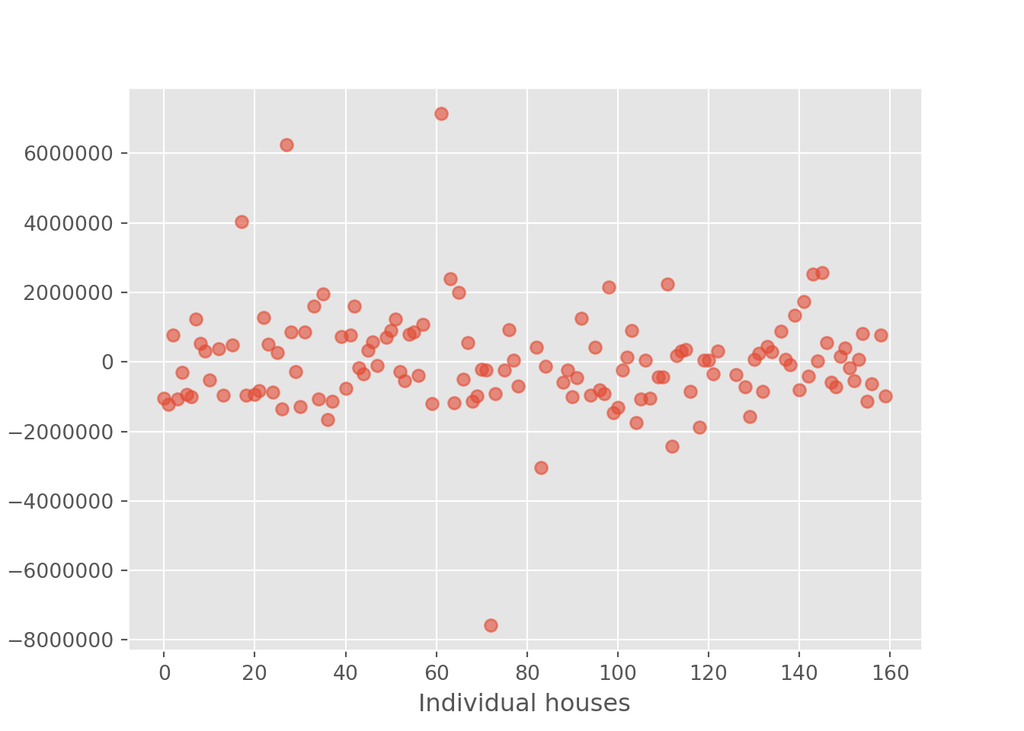

```python
fig,ax = plt.subplots()

ax.plot(housePricePredictions.difference, "o", alpha=0.6)
ax.set_ylabel("True - Predicted price ($)")
ax.set_xlabel("Individual houses")

plt.show()
```

## 2.4 Adding even more features: One-hot encoding of the zip code

Let’s try to improve those prediction by adding the zip code, encoded as hotshot.

```python
dataEncoded = dataHouses[np.concatenate([["price", "zip"], featuresOfInterest])].dropna().assign(zip90401 = lambda x: (x.zip==90401).astype(int))
dataEncoded = dataEncoded.assign(zip90402 = lambda x: (x.zip==90402).astype(int))
dataEncoded = dataEncoded.assign(zip90403 = lambda x: (x.zip==90403).astype(int))
dataEncoded = dataEncoded.assign(zip90404 = lambda x: (x.zip==90404).astype(int))
dataEncoded = dataEncoded.assign(zip90405 = lambda x: (x.zip==90405).astype(int))
dataEncoded.loc[:, featuresOfInterest] = (dataEncoded.loc[:, featuresOfInterest]-dataEncoded.loc[:, featuresOfInterest].mean())/dataEncoded.loc[:, featuresOfInterest].std()
```

Features list

|  | price | zip | sqft | bedrooms | bathrooms | zip90401 | zip90402 | zip90403 | zip90404 | zip90405 |
| --- | --- | --- | --- | --- | --- | --- | --- | --- | --- | --- |
| 0 | 698000 | 90403 | -0.832 | -0.841 | -0.861 | 0 | 0 | 1 | 0 | 0 |
| 1 | 1099000 | 90403 | -0.586 | -0.554 | -0.283 | 0 | 0 | 1 | 0 | 0 |
| 2 | 2999000 | 90402 | -0.520 | -0.554 | -0.572 | 0 | 1 | 0 | 0 | 0 |
| 3 | 680000 | 90403 | -0.762 | -0.554 | -0.572 | 0 | 0 | 1 | 0 | 0 |
| 4 | 2200000 | 90405 | -0.314 | -0.266 | -0.283 | 0 | 0 | 0 | 0 | 1 |
| 5 | 849000 | 90403 | -0.737 | -0.554 | -0.572 | 0 | 0 | 1 | 0 | 0 |
| 6 | 549000 | 90401 | -0.930 | -0.841 | -0.861 | 1 | 0 | 0 | 0 | 0 |
| 7 | 7895000 | 90402 | 1.751 | 0.596 | 1.163 | 0 | 1 | 0 | 0 | 0 |
| 8 | 2329000 | 90403 | -0.556 | -0.266 | -0.572 | 0 | 0 | 1 | 0 | 0 |
| 9 | 2695000 | 90404 | -0.118 | 0.309 | 0.006 | 0 | 0 | 0 | 1 | 0 |
| 10 | 1049000 | 90403 | -0.664 | -0.266 | -0.572 | 0 | 0 | 1 | 0 | 0 |
| 12 | 2795000 | 90405 | -0.174 | 0.021 | -0.283 | 0 | 0 | 0 | 0 | 1 |
| 13 | 819000 | 90403 | -0.747 | -0.554 | -0.572 | 0 | 0 | 1 | 0 | 0 |
| 15 | 9300000 | 90404 | 4.683 | 6.346 | 5.788 | 0 | 0 | 0 | 1 | 0 |
| 17 | 6495000 | 90402 | -0.229 | -0.266 | -0.572 | 0 | 1 | 0 | 0 | 0 |
| 18 | 1299000 | 90404 | -0.436 | -0.266 | -0.283 | 0 | 0 | 0 | 1 | 0 |
| 20 | 639000 | 90403 | -0.918 | -0.841 | -0.861 | 0 | 0 | 1 | 0 | 0 |
| 21 | 925000 | 90405 | -0.763 | -0.554 | -0.572 | 0 | 0 | 0 | 0 | 1 |
| 22 | 3695000 | 90402 | 0.064 | 0.309 | -0.427 | 0 | 1 | 0 | 0 | 0 |
| 23 | 3795000 | 90402 | 0.079 | -0.266 | -0.283 | 0 | 1 | 0 | 0 | 0 |
| 24 | 1200000 | 90403 | -0.602 | -0.554 | -0.572 | 0 | 0 | 1 | 0 | 0 |
| 25 | 1969000 | 90405 | -0.422 | 0.021 | -0.572 | 0 | 0 | 0 | 0 | 1 |
| 26 | 1725000 | 90404 | 0.111 | 0.309 | 0.296 | 0 | 0 | 0 | 1 | 0 |
| 27 | 12495000 | 90402 | 1.429 | 0.596 | 1.452 | 0 | 1 | 0 | 0 | 0 |
| 28 | 9125000 | 90404 | 3.299 | 3.184 | 3.476 | 0 | 0 | 0 | 1 | 0 |
| 29 | 3850000 | 90405 | 0.635 | 0.309 | 0.296 | 0 | 0 | 0 | 0 | 1 |
| 30 | 899000 | 90401 | -0.649 | -0.554 | -0.283 | 1 | 0 | 0 | 0 | 0 |
| 31 | 3269000 | 90402 | -0.358 | -0.266 | -0.283 | 0 | 1 | 0 | 0 | 0 |
| 33 | 6500000 | 90402 | 0.794 | 0.309 | 0.874 | 0 | 1 | 0 | 0 | 0 |
| 34 | 539000 | 90404 | -0.899 | -0.841 | -0.861 | 0 | 0 | 0 | 1 | 0 |

[output cut: 104 more lines]

And let’s run gradient descent again and see how this affected our predictions.

```python
# features now also includes number of beds and number of bathrooms
features = np.hstack([np.ones(len(dataEncoded))[:, np.newaxis], dataEncoded.loc[:, "sqft":].values])
trueValues = dataEncoded.price.values[:, np.newaxis]

# Initial theta values we'll start iterating from. We now have 3 features, so must be size 4
initialTheta = np.random.rand(features.shape[1])[:, np.newaxis]

# we'll run gradient descent with different alpha rates
alphaList = [0.005, 0.01, 0.05]

gdList = [gradientDescent(initialTheta, features, trueValues, alpha=i, maxIterations=1000) for i in alphaList]
descentList = [np.vstack([initialTheta.transpose(), np.vstack(list(gd))]) for gd in gdList]
```

```python
fig,ax = plt.subplots()

n = 400
for i in range(len(alphaList)):
    theta = descentList[i].transpose()
    ax.plot(np.ravel(computeCost(theta, features, trueValues)), label=r"$\alpha$" f"={alphaList[i]}")
ax.set_xlim(0, n)
```

```
## (0, 400)
```

```python
ax.set_ylim(0, 0.8e13)
```

```
## (0, 8000000000000.0)
```

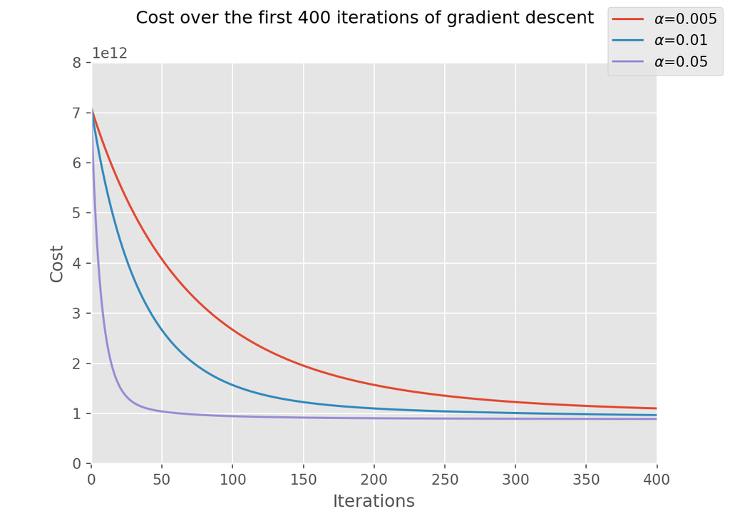

```python
ax.set_xlabel("Iterations")
ax.set_ylabel("Cost")
fig.suptitle(f"Cost over the first {n} iterations of gradient descent")
fig.legend();
plt.show()
```

```python
# let's get the theta obtained with alph=0.2
fittedTheta = descentList[2][-1][:, np.newaxis]

predictions = features@fittedTheta

print(f"RMSE: {rmse(trueValues, predictions):2f}")
```

```
## RMSE: 1332921.249782
```

The $RMSE$ is even smaller now.

```python
housePricePredictions2 = dataEncoded.loc[:, ["price"]].assign(predicted= lambda x: features@fittedTheta)
housePricePredictions2["difference"] = housePricePredictions2.price-housePricePredictions.predicted
```

Features list

|  | price | predicted | difference |
| --- | --- | --- | --- |
| 0 | 698000 | 1112634.7 | -1047006.86 |
| 1 | 1099000 | 1700479.3 | -1221743.04 |
| 2 | 2999000 | 3218654.5 | 769605.53 |
| 3 | 680000 | 1219213.1 | -1062106.81 |
| 4 | 2200000 | 2073155.7 | -302091.54 |
| 5 | 849000 | 1256968.2 | -945030.91 |
| 6 | 549000 | 2191085.8 | -999494.14 |
| 7 | 7895000 | 7004660.0 | 1223152.67 |
| 8 | 2329000 | 1303395.1 | 537352.00 |
| 9 | 2695000 | 1982373.9 | 310027.94 |
| 10 | 1049000 | 1144242.7 | -523767.97 |
| 12 | 2795000 | 2059174.4 | 378369.92 |
| 13 | 819000 | 1241285.3 | -953462.44 |
| 15 | 9300000 | 8876272.7 | 489693.01 |
| 17 | 6495000 | 3427137.9 | 4045114.25 |
| 18 | 1299000 | 1731786.2 | -957051.21 |
| 20 | 639000 | 987752.4 | -934257.94 |
| 21 | 925000 | 1411286.7 | -816307.98 |
| 22 | 3695000 | 3530318.6 | 1277298.94 |
| 23 | 3795000 | 4100084.0 | 502863.39 |
| 24 | 1200000 | 1453875.6 | -864835.03 |
| 25 | 1969000 | 1473355.5 | 274795.95 |
| 26 | 1725000 | 2540312.1 | -1344054.15 |
| 27 | 12495000 | 6756381.2 | 6247849.73 |
| 28 | 9125000 | 7471382.2 | 852313.58 |
| 29 | 3850000 | 3469499.7 | -273512.69 |
| 30 | 899000 | 2828883.3 | -1293929.88 |
| 31 | 3269000 | 3461151.3 | 855578.84 |
| 33 | 6500000 | 5599886.4 | 1610642.65 |
| 34 | 539000 | 1045819.2 | -1072601.88 |

[output cut: 104 more lines]

```python
import altair as alt

housesPredChart2 = alt.Chart(housePricePredictions2).mark_circle().encode(
    x='price',
    y='predicted',
    size='difference',
    tooltip = alt.Tooltip(['price:Q', 'predicted:Q', 'difference:Q'], format= "s")
    ).configure_mark(opacity=0.7).interactive()
```

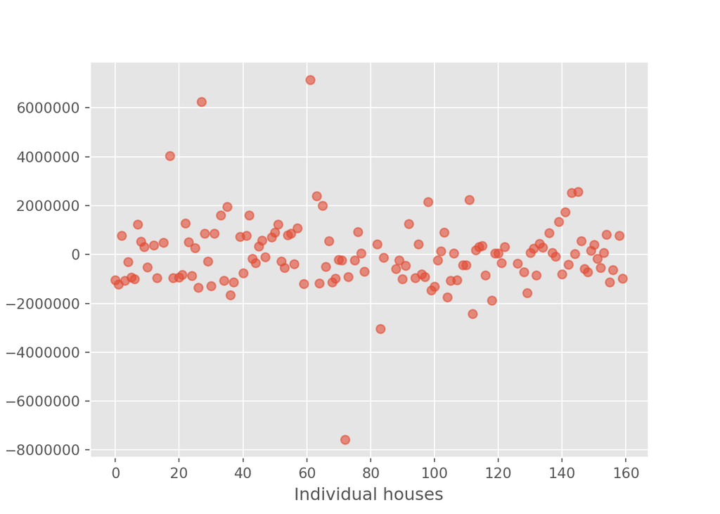

```python
fig,ax = plt.subplots()

ax.plot(housePricePredictions2.difference, "o", alpha=0.6)
ax.set_ylabel("True - Predicted price ($)")
ax.set_xlabel("Individual houses")

plt.show()
```

# 3 Comparing with `Scikit-Learn`

Of course, implementing linear regression with gradient descent was more of a fun exercice to better understand what’s happening under the hood. Most of the ML algorithm are already implemented in dedicated libraries like `scikit-learn`.

Let’s see for example how the predictions we made compare to the ones obtained on the same dataset (and using the same features) with `scikit-learn`.

```python
from sklearn import linear_model

x_train = dataEncoded.loc[:, "sqft":].values
y_train = dataEncoded.loc[:, "price"].values

ols = linear_model.LinearRegression()
model = ols.fit(x_train, y_train)
```

```python
predictionsCompared = dataEncoded.loc[:, ["price"]].assign(manual = lambda x: features@fittedTheta).assign(sklearn= lambda x: model.predict(dataEncoded.loc[:, "sqft":].values))
```

Manual vs Scikit-Learn

|  | price | manual | sklearn |
| --- | --- | --- | --- |
| 0 | 698000 | 1112634.7 | 1110926.5 |
| 1 | 1099000 | 1700479.3 | 1701139.5 |
| 2 | 2999000 | 3218654.5 | 3214855.0 |
| 3 | 680000 | 1219213.1 | 1217260.5 |
| 4 | 2200000 | 2073155.7 | 2073267.1 |
| 5 | 849000 | 1256968.2 | 1255056.4 |
| 6 | 549000 | 2191085.8 | 2208657.8 |
| 7 | 7895000 | 7004660.0 | 7007701.7 |
| 8 | 2329000 | 1303395.1 | 1299081.7 |
| 9 | 2695000 | 1982373.9 | 1980081.9 |
| 10 | 1049000 | 1144242.7 | 1139757.2 |
| 12 | 2795000 | 2059174.4 | 2056818.9 |
| 13 | 819000 | 1241285.3 | 1239356.6 |
| 15 | 9300000 | 8876272.7 | 8871792.9 |
| 17 | 6495000 | 3427137.9 | 3421112.2 |
| 18 | 1299000 | 1731786.2 | 1732034.6 |
| 20 | 639000 | 987752.4 | 985909.1 |
| 21 | 925000 | 1411286.7 | 1411041.8 |
| 22 | 3695000 | 3530318.6 | 3520547.0 |
| 23 | 3795000 | 4100084.0 | 4096878.4 |
| 24 | 1200000 | 1453875.6 | 1452176.9 |
| 25 | 1969000 | 1473355.5 | 1468274.2 |
| 26 | 1725000 | 2540312.1 | 2540715.8 |
| 27 | 12495000 | 6756381.2 | 6761246.4 |
| 28 | 9125000 | 7471382.2 | 7475615.5 |
| 29 | 3850000 | 3469499.7 | 3470402.3 |
| 30 | 899000 | 2828883.3 | 2848877.8 |
| 31 | 3269000 | 3461151.3 | 3457254.5 |
| 33 | 6500000 | 5599886.4 | 5601768.1 |
| 34 | 539000 | 1045819.2 | 1046045.0 |

[output cut: 104 more lines]

Pretty good! Sounds like we did a good job at implementing the algorithm!

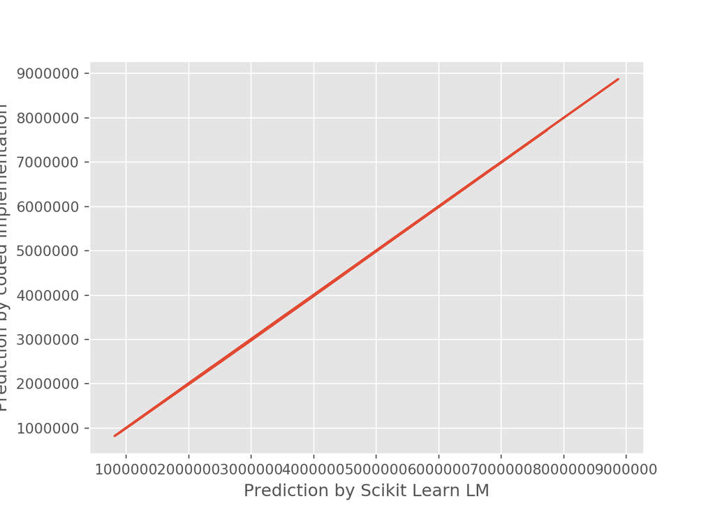

```python
fig,ax = plt.subplots()
ax.plot(model.predict(dataEncoded.loc[:, "sqft":].values), features@fittedTheta)
ax.set_xlabel("Prediction by Scikit Learn LM")
ax.set_ylabel("Prediction by coded implementation")
plt.show()
```